# Code to reproduce results in *Semi-parametric generalized linear model for binomial data with varying cluster sizes*

Aniko Szabo

```r
knitr::opts_chunk$set(echo = TRUE, cache=TRUE, autodep=TRUE)

library(exchreg)
library(knitr)
library(dplyr)
library(tidyr)
library(ggplot2)
theme_set(theme_classic())

library(CorrBin) ## utilities for working with correlated binomial data
library(VGAM) ## for beta-binomial regression
library(geepack)  ## for GEE

set.seed(20211223)
data(boric_acid)
```

# Application to boric acid developmental toxicity data

The boric acid data is included in the package as an example dataset `boric_acid`. We fit a GEE, beta-binomial, and semi-parameteric GLM model with a logit-link.

```r
boric_acid$Trt <- factor(boric_acid$Trt, levels=c("0","0.1", "0.2","0.4"),
                         labels = c("0%", "0.1%", "0.2%", "0.4%"))
# convert data into one-row per cluster-member format needed for GEE
ba_long <- unwrap(boric_acid)

# run GEE
ba_gee <- geeglm(Resp ~ Trt, data=ba_long, id = ID, family=binomial,
                 corstr = "exch")
ba_gee
```

```
##
## Call:
## geeglm(formula = Resp ~ Trt, family = binomial, data = ba_long,
##     id = ID, corstr = "exch")
##
## Coefficients:
## (Intercept)     Trt0.1%     Trt0.2%     Trt0.4%
##  -2.3872351   0.5278181  -0.2125692   1.4191331
##
## Degrees of Freedom: 1000 Total (i.e. Null);  996 Residual
##
## Scale Link:                   identity
## Estimated Scale Parameters:  [1] 0.9958515
##
## Correlation:  Structure = exchangeable    Link = identity
## Estimated Correlation Parameters:
##      alpha
## 0.08986404
##
## Number of clusters:   83   Maximum cluster size: 16
```

```r
# fit beta-binomial model
ba_bb <- vgam(cbind(NResp, ClusterSize - NResp) ~ Trt, weights = Freq,
                 data=boric_acid, family =  betabinomial(lmu="logitlink"))
summaryvglm(ba_bb)
```

```
##
## Call:
## vgam(formula = cbind(NResp, ClusterSize - NResp) ~ Trt, family = betabinomial(lmu = "logitlink"),
##     data = boric_acid, weights = Freq)
##
## Coefficients:
##               Estimate Std. Error z value Pr(>|z|)
## (Intercept):1  -2.1944     0.2911  -7.539 4.74e-14 ***
## (Intercept):2  -2.2011     0.3293  -6.684 2.33e-11 ***
## Trt0.1%         0.3832     0.3716   1.031  0.30245
## Trt0.2%        -0.3013     0.4494  -0.670  0.50255
## Trt0.4%         1.1703     0.3575   3.274  0.00106 **
## ---
## Signif. codes:  0 '***' 0.001 '**' 0.01 '*' 0.05 '.' 0.1 ' ' 1
##
## Names of linear predictors: logitlink(mu), logitlink(rho)
##
## Log-likelihood: -141.0241 on 129 degrees of freedom
##
## Number of Fisher scoring iterations: 6
##
## No Hauck-Donner effect found in any of the estimates
```

```r
ba_spglm <- spglm(cbind(NResp, ClusterSize - NResp) ~ Trt, data=boric_acid,
                  weights  = Freq)

ba_spglm
```

```
##
## A semi-parametric generalized linear regression model fit
##
## Call:
## spglm(formula = cbind(NResp, ClusterSize - NResp) ~ Trt, data = boric_acid,
##     weights = Freq)
##
## Coefficients:
##             Estimate Std. Error z value Pr(>|z|)
## (Intercept)  -2.3953     0.2765  -8.662  < 2e-16 ***
## Trt0.1%       0.5333     0.3550   1.502 0.133053
## Trt0.2%      -0.2074     0.4199  -0.494 0.621306
## Trt0.4%       1.4268     0.3924   3.636 0.000277 ***
## ---
## Signif. codes:  0 '***' 0.001 '**' 0.01 '*' 0.05 '.' 0.1 ' ' 1
##
##  Baseline probabilities (q0):
##         0          1          2          3          4          5          6
## 1.743e-01  3.092e-01  5.386e-02  2.106e-01  1.761e-01  8.214e-03  5.624e-02
##         7          8          9         10         11         12         13
## 2.184e-06  4.194e-08  2.996e-08  2.259e-05  1.013e-02  5.963e-08  5.148e-09
##        14         15         16
## 2.708e-11  3.285e-10  1.335e-03
##
##  Log-likelihood:  -130
```

```r
table1 <- list(GEE = cbind(Est = coef(ba_gee), SE=sqrt(diag(vcov(ba_gee)))),
                BB = cbind(Est = coef(ba_bb)[-2],      # second value is logit(rho)
                           SE=sqrt(diag(vcov(ba_bb)))[-2]),
                SPGLM = cbind(Est = coef(ba_spglm), SE=sqrt(diag(vcov(ba_spglm)))))
table1
```

```
## $GEE
##                    Est        SE
## (Intercept) -2.3872351 0.2347839
## Trt0.1%      0.5278181 0.3211938
## Trt0.2%     -0.2125692 0.3980928
## Trt0.4%      1.4191331 0.3711894
##
## $BB
##                      Est        SE
## (Intercept):1 -2.1944033 0.2910818
## Trt0.1%        0.3832322 0.3716402
## Trt0.2%       -0.3013220 0.4494087
## Trt0.4%        1.1703093 0.3574712
##
## $SPGLM
##                    Est        SE
## (Intercept) -2.3952614 0.2765409
## Trt0.1%      0.5332500 0.3549862
## Trt0.2%     -0.2074087 0.4198560
## Trt0.4%      1.4267661 0.3924455
```

```r
table1 <- data.frame(GEE = cbind(Est = coef(ba_gee), SE=sqrt(diag(vcov(ba_gee)))),
                BB = cbind(Est = coef(ba_bb)[-2],      # second value is logit(rho)
                           SE=sqrt(diag(vcov(ba_bb)))[-2]),
                SPGLM = cbind(Est = coef(ba_spglm), SE=sqrt(diag(vcov(ba_spglm)))))
kable(table1, digits=3)
```

[output not shown]

Fitted values for the outcome probabilities can be obtained for the SPGLM and Beta-binomial models, as well as using non-parametric estimates within each group.

```r
newd <- data.frame(Trt=unique(boric_acid$Trt))

# beta-binomial
mns_rho <- predictvglm(ba_bb, type="link", newdata=newd, untransform=TRUE)

fit_bb <- tibble(newd, as_tibble(mns_rho)) %>%
  group_by(Trt) %>%
  mutate(ClusterSize = 10,
         NResp = list(0:10),
         Prob = list(dbetabinom(0:10, size=10, prob=mu, rho=rho))) %>%
  unnest(cols=c(NResp, Prob)) %>%
  mutate(Model="Beta-binomial")
```

```r
fit_spglm <- crossing(newd, NResp=0:10) %>%
  mutate(ClusterSize = 10,
         Prob = predict(ba_spglm, newdata=., type="prob",
                          newn=ClusterSize, newevents = NResp),
         Model = "SPGLM")
```

```r
fit_nonpar <- mc.est(boric_acid) %>%
  filter(ClusterSize == 10) %>%
  mutate(Model="Non-parametric")
```

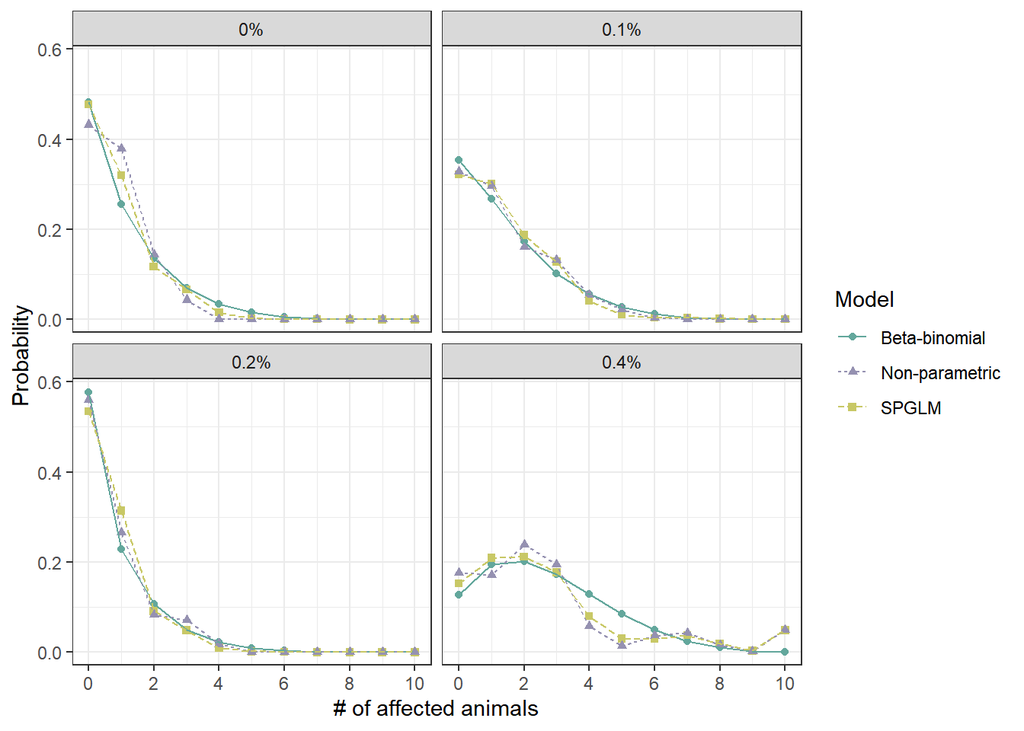

```r
fits <- bind_rows(fit_bb, fit_spglm, fit_nonpar)

linecols <- colorspace::darken(RColorBrewer::brewer.pal(3, "Set3"), 0.2)
names(linecols) <- unique(fits$Model)

ggplot(fits, aes(x=NResp, y=Prob, colour=Model, shape=Model, linetype=Model)) +
  facet_wrap(~Trt) +
  geom_point() +
  geom_line() +
  scale_x_continuous("# of affected animals", breaks=seq(0,10,by=2)) +
  scale_colour_manual(values=linecols) +
  ylab("Probability") +
  theme_bw()
```

# Simulation study

Goal:

- simulate data with four settings:
1. Both the parametric (binomial) and semi-parameteric model are correct - a binomial backbone, which belongs to the exponential family
2. Only the parametric (beta-binomial) model is correct - generated from a beta-binomial distribution
3. Only the semi-parametric model is correct - generated from the spglm, with a q-power backbone
4. Neither model is correct - generated from a q-power distribution
- fit the data using our semi-parametric regression model, beta-binomial regression (potentially misspecified distribution), and GEE (marginal only)

## Simulating data

We will have one binary predictor $X_1 \sim Bern(0.5)$ with $\beta_1=0.5$ and one continuous predictor $X_2 \sim N(0,1)$ with $\beta_2 = 1$. The cluster size distribution will be binomial.

```r
R <- 500
beta_correct <- c(0, 0.5, 1)
cs_predict <- 5
p_predict <- 1/(1+exp(-c(beta_correct %*% c(0,0,0))))
```

```r
sim_covariates <- function(n, maxClusterSize = 10, aveClusterSize = 7, beta=beta_correct){
  x1 <- rbinom(n, size=1, prob=0.5)
  x2 <- rnorm(n)
  lp <- cbind(1, x1, x2) %*% beta
  mns <- 1/(1+exp(-lp))

  cs <- rbinom(n, size=maxClusterSize, prob=aveClusterSize/maxClusterSize)
  cs <- pmax(1, cs) # don't want clusters of size 0

  data.frame(ClusterSize = cs, X1=x1, X2=x2, p_resp = mns)
}

# add random response counts using SPGLM model
add_response_spglm <- function(cov_data, q0){
  # cov_data should come from sim_covariates

  simres <- ran.spglm(n=cov_data$ClusterSize, means = cov_data$p_resp, q0 = q0)
  res <- cov_data
  res$NResp <- simres$NResp
  res$Trt <- "All"
  res$Freq <- 1
  class(res) <- c("CBData", class(res))
  res
}

# add random response counts from binomial, beta-binomial, or q-power
add_response_param <- function(cov_data, rfun=function(n, cs, p)rbinom(n, size=cs, prob=p)){
  # cov_data should come from sim_covariates

  res <- cov_data
  res$NResp <- rfun(n = nrow(cov_data),
                    cs = cov_data$ClusterSize,
                    p = cov_data$p_resp)
  res$Trt <- "All"
  res$Freq <- 1
  class(res) <- c("CBData", class(res))
  res
}

# random number generation from the q-power pdf
rqpower <- function(n, size, prob, rho){
  size <- rep(size, length.out = n)
  prob <- rep(prob, length.out = n)
  rho <- rep(rho, length.out = n)

  res <- mapply(
    function(s,p,r){
      pdf <- qpower.pdf(p=p, rho=r, n=s)
      sample(0:s, size=1, prob=pdf)},
    size, prob, rho)
  res
}
```

## Analyzing a simulated dataset

```r
run_analysis <- function(dat, cs_predict=5, Binom = FALSE){
  #GEE
  dat_long <- unwrap(dat)
  res_gee <- geeglm(Resp ~ X1 + X2, data=dat_long, id = ID, family=binomial,
                 corstr = "exch")

  if (Binom){
    #Binomial
    res_bin <- glm(cbind(NResp, ClusterSize - NResp) ~  X1 + X2, weights = Freq,
                  data=dat, family =  binomial)
  } else {
    #Beta-binomial
    res_bb <- vgam(cbind(NResp, ClusterSize - NResp) ~  X1 + X2, weights = Freq,
                 data=dat, family =  betabinomial(lmu="logitlink"))
  }

  #SPGLM
  op <- options(warn=-1)
  res_spglm <- spglm(cbind(NResp, ClusterSize - NResp) ~ X1 + X2, data=dat,
                   weights  = Freq)
  options(op)

  # predict PDF at cluster-size cs_predict & all covariates = 0
  newd <- data.frame(X1 = 0, X2 = 0)
  nms <- names(coef(res_spglm))

  if (Binom){
    # binomial
    mns <- predict(res_bin, type="response", newdata=newd)

   fit_binbb <- newd %>%
      crossing(NResp=0:cs_predict) %>%
      mutate(ClusterSize = cs_predict,
            Prob = dbinom(NResp, size=cs_predict, prob=mns)) %>%
    mutate(Model="Binom/BB")

   ests_binbb <- tibble(Term = nms,
                 Est = coef(res_bin),
                 SE = sqrt(diag(vcov(res_bin))))
  } else {
    # beta-binomial
    mns_rho <- predictvglm(res_bb, type="link", newdata=newd, untransform=TRUE)

    fit_binbb <- newd %>%
      crossing(NResp=0:cs_predict) %>%
      mutate(ClusterSize = cs_predict,
            Prob = dbetabinom(NResp, size=cs_predict, prob=mns_rho[1,"mu"],
                              rho=mns_rho[1,"rho"])) %>%
    mutate(Model="Binom/BB")

    ests_binbb <- tibble(Term = nms,
                Est = coef(res_bb)[-2],      # second value is logit(rho)
                SE=sqrt(diag(vcov(res_bb)))[-2])
  }



  fit_spglm <- newd %>%
    crossing(NResp=0:cs_predict) %>%
    mutate(ClusterSize = cs_predict,
           Prob = predict(res_spglm, newdata=., type="prob",
                          newn=ClusterSize, newevents = NResp),
           Model = "SPGLM")

  res <- bind_rows(
    GEE = tibble(Term = nms,
                 Est=coef(res_gee),
                 SE = sqrt(diag(vcov(res_gee)))),
    `Binom/BB` = ests_binbb,
    SPGLM = tibble(Term = nms,
                   Est = coef(res_spglm),
                   SE= sqrt(diag(vcov(res_spglm)))),
    .id = "Model")

  fit <- bind_rows(fit_binbb, fit_spglm) %>%
    mutate(Type = "PDF")

  out <- res %>%
    mutate(Type = "Beta") %>%
    bind_rows(fit %>%
                mutate(Term = as.character(NResp)) %>%
                select(Type, Model, Term, Est=Prob))


  out
}
```

## Run simulations

```r
set.seed(20211223)
# Scenario 1: binomial PDF
sim1 <-
  replicate(R,
            {simd <- sim_covariates(100) %>%
                add_response_param(rfun=function(n, cs, p)rbinom(n, size=cs, prob=p));
             run_analysis(simd, cs_predict = cs_predict, Binom = TRUE)},
            simplify = FALSE)  %>%
   bind_rows(.id="ID")

pdf1 <- tibble(NResp = 0:cs_predict) %>%
  mutate(Correct = dbinom(NResp, size=cs_predict, prob=p_predict))
```

```r
set.seed(20211223)
# Scenario 2: beta-binomial PDF
sim2 <-
  replicate(R,
            {simd <- sim_covariates(100) %>%
                add_response_param(rfun=function(n, cs, p)rbetabinom(n, size=cs, prob=p, rho=0.3));
             run_analysis(simd, cs_predict = cs_predict)},
            simplify = FALSE) %>%
   bind_rows(.id="ID")

pdf2 <- tibble(NResp = 0:cs_predict) %>%
  mutate(Correct = dbetabinom(NResp, size=cs_predict, prob=p_predict, rho=0.3))
```

```r
set.seed(20211223)
# Scenario 3: SPGLM with q-power backbone
sim3 <-
  replicate(R,
            {simd <- sim_covariates(100) %>%
              add_response_spglm(q0 = qpower.pdf(n=10, p=0.4, rho = 0.3));
             run_analysis(simd, cs_predict = cs_predict)},
            simplify = FALSE)  %>%
   bind_rows(.id="ID")

# simulation-based pdf
pdf3 <- ran.spglm(n=rep(cs_predict, 1e6), means = rep(p_predict, 1e6),
                  q0 = qpower.pdf(n=10, p=0.4, rho = 0.3)) %>%
  count(NResp) %>%
  mutate(Correct = n/sum(n)) %>%
  select(-n)
```

```r
set.seed(20211223)
# Scenario 4: q-power
sim4 <-
  replicate(R,
            {simd <- sim_covariates(100) %>%
                add_response_param(rfun=function(n, cs, p)rqpower(n, size=cs, prob=p, rho=0.3));
             run_analysis(simd, cs_predict = cs_predict)},
            simplify = FALSE)  %>%
   bind_rows(.id="ID")

pdf4 <- tibble(NResp = 0:cs_predict) %>%
  mutate(Correct = qpower.pdf(n=cs_predict, p=p_predict, rho=0.3))
```

## Compare results

```r
comb <- bind_rows(`Both correct` = sim1,
                  `Parametric correct`= sim2,
                  `SPGLM correct` = sim3,
                  `Neither correct` = sim4,
                  .id="Generator") %>%
  mutate(Generator= factor(Generator, levels = c("Both correct",
                                                 "Parametric correct",
                                                 "SPGLM correct",
                                                 "Neither correct")),
         Model = factor(Model, levels = c("Binom/BB","SPGLM","GEE")))

# get correct values of parameters
correct_beta <- tibble(Term = c("(Intercept)","X1","X2"),
                  Correct = beta_correct)
correct_pdf <- bind_rows(`Both correct` = pdf1,
                         `Parametric correct`= pdf2,
                         `SPGLM correct` = pdf3,
                         `Neither correct` = pdf4,
                         .id="Generator") %>%
  mutate(Term = as.character(NResp),
         Generator= factor(Generator, levels = c("Both correct",
                                                 "Parametric correct",
                                                 "SPGLM correct",
                                                 "Neither correct")))

comb_beta <- left_join(comb %>% filter(Type == "Beta"), correct_beta, by="Term") %>%
  mutate(Coefficient = recode(Term, "(Intercept)" = "beta[0]",
                              "X1"="beta[1]",
                              X2="beta[2]"),
         Term = recode(Term,  "(Intercept)" = "$\\beta_0$",
                       "X1"="$\\beta_1$",
                       X2="$\\beta_2$"))

comb_pdf <- left_join(comb %>% filter(Type=="PDF"),
                      correct_pdf, by=c("Term","Generator"))


scomb <- comb_beta %>%
  group_by(Generator, Term, Model) %>%
  summarize(bias = mean(Est-Correct, na.rm=TRUE),
            mc.se = sd(Est, na.rm=TRUE),
            se = mean(SE, na.rm=TRUE),
            .groups="drop_last") %>%
  mutate(rel.eff = mc.se / mc.se[Model=="GEE"]) %>%
  ungroup() %>%
  arrange(Generator, Model, Term)
kable(scomb, digits=3)
```

| Generator | Term | Model | bias | mc.se | se | rel.eff |
| --- | --- | --- | --- | --- | --- | --- |
| Both correct | $\beta_0$ | Binom/BB | 0.002 | 0.125 | 0.119 | 0.997 |
| Both correct | $\beta_1$ | Binom/BB | 0.006 | 0.167 | 0.171 | 0.998 |
| Both correct | $\beta_2$ | Binom/BB | 0.009 | 0.099 | 0.102 | 1.000 |
| Both correct | $\beta_0$ | SPGLM | 0.001 | 0.130 | 0.111 | 1.043 |
| Both correct | $\beta_1$ | SPGLM | 0.007 | 0.175 | 0.164 | 1.046 |
| Both correct | $\beta_2$ | SPGLM | 0.014 | 0.103 | 0.098 | 1.036 |
| Both correct | $\beta_0$ | GEE | 0.002 | 0.125 | 0.117 | 1.000 |
| Both correct | $\beta_1$ | GEE | 0.007 | 0.168 | 0.168 | 1.000 |
| Both correct | $\beta_2$ | GEE | 0.009 | 0.099 | 0.100 | 1.000 |
| Parametric correct | $\beta_0$ | Binom/BB | 0.005 | 0.195 | 0.193 | 0.971 |
| Parametric correct | $\beta_1$ | Binom/BB | 0.005 | 0.284 | 0.278 | 0.978 |
| Parametric correct | $\beta_2$ | Binom/BB | 0.020 | 0.176 | 0.165 | 0.958 |
| Parametric correct | $\beta_0$ | SPGLM | 0.003 | 0.203 | 0.197 | 1.011 |
| Parametric correct | $\beta_1$ | SPGLM | 0.009 | 0.294 | 0.284 | 1.014 |
| Parametric correct | $\beta_2$ | SPGLM | 0.027 | 0.188 | 0.160 | 1.025 |
| Parametric correct | $\beta_0$ | GEE | 0.004 | 0.201 | 0.198 | 1.000 |
| Parametric correct | $\beta_1$ | GEE | 0.007 | 0.290 | 0.285 | 1.000 |
| Parametric correct | $\beta_2$ | GEE | 0.020 | 0.184 | 0.169 | 1.000 |
| SPGLM correct | $\beta_0$ | Binom/BB | 0.088 | 0.192 | 0.196 | 0.976 |
| SPGLM correct | $\beta_1$ | Binom/BB | -0.002 | 0.295 | 0.283 | 0.973 |
| SPGLM correct | $\beta_2$ | Binom/BB | -0.044 | 0.162 | 0.165 | 0.937 |
| SPGLM correct | $\beta_0$ | SPGLM | -0.008 | 0.196 | 0.195 | 0.999 |
| SPGLM correct | $\beta_1$ | SPGLM | 0.027 | 0.299 | 0.284 | 0.988 |
| SPGLM correct | $\beta_2$ | SPGLM | 0.014 | 0.171 | 0.157 | 0.989 |
| SPGLM correct | $\beta_0$ | GEE | -0.009 | 0.197 | 0.199 | 1.000 |
| SPGLM correct | $\beta_1$ | GEE | 0.027 | 0.303 | 0.292 | 1.000 |
| SPGLM correct | $\beta_2$ | GEE | 0.012 | 0.173 | 0.161 | 1.000 |
| Neither correct | $\beta_0$ | Binom/BB | 0.059 | 0.211 | 0.193 | 0.980 |
| Neither correct | $\beta_1$ | Binom/BB | 0.007 | 0.292 | 0.277 | 0.989 |
| Neither correct | $\beta_2$ | Binom/BB | 0.005 | 0.162 | 0.164 | 0.960 |
| Neither correct | $\beta_0$ | SPGLM | 0.008 | 0.219 | 0.193 | 1.018 |
| Neither correct | $\beta_1$ | SPGLM | 0.010 | 0.306 | 0.281 | 1.035 |
| Neither correct | $\beta_2$ | SPGLM | 0.022 | 0.178 | 0.157 | 1.053 |
| Neither correct | $\beta_0$ | GEE | 0.005 | 0.215 | 0.197 | 1.000 |
| Neither correct | $\beta_1$ | GEE | 0.013 | 0.295 | 0.284 | 1.000 |
| Neither correct | $\beta_2$ | GEE | 0.023 | 0.169 | 0.169 | 1.000 |

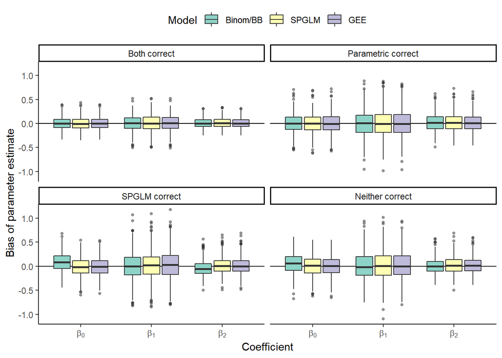

```r
cols <- RColorBrewer::brewer.pal(3, "Set3")
names(cols) <- levels(comb$Model)
ggplot(comb_beta, aes(x=Coefficient, y=Est-Correct, fill=Model, outlier.fill=Model)) +
  facet_wrap(~Generator) +
  geom_hline(aes(yintercept=0)) +
  geom_boxplot(position=position_dodge(width=0.8), width=0.7,
               outlier.size =1, outlier.alpha=0.5) +
  scale_x_discrete(labels = scales::label_parse()) +
  scale_y_continuous("Bias of parameter estimate") +
  scale_fill_manual(breaks=names(cols), values=cols) +
  theme(legend.position = "top")
```

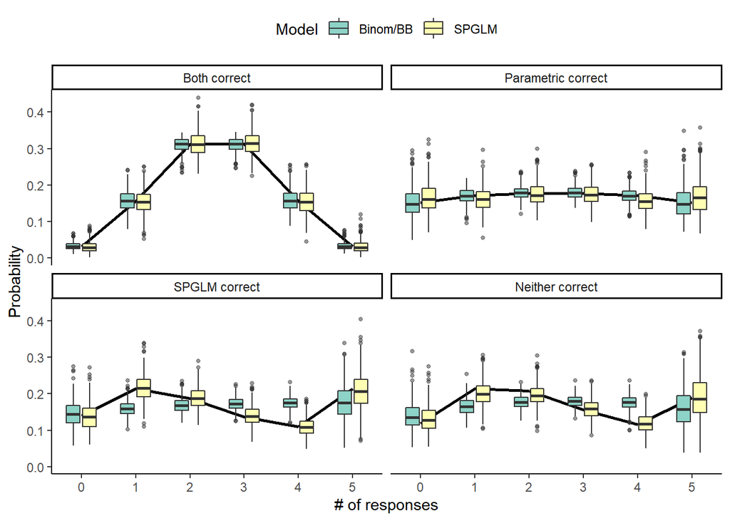

```r
ggplot(comb_pdf, aes(x=NResp, y=Est, fill=Model, outlier.fill=Model)) +
  facet_wrap(~Generator) +
  geom_line(aes(y=Correct), colour="black", size=1) +
  geom_boxplot(aes(group=interaction(Model, NResp)),
               position=position_dodge(width=0.6), width=0.5,
               outlier.size =1, outlier.alpha=0.5) +
  scale_y_continuous("Probability") +
  scale_x_continuous("# of responses", breaks = 0:cs_predict) +
  scale_fill_manual(breaks=names(cols), values=cols)  +
  theme(legend.position = "top")
```

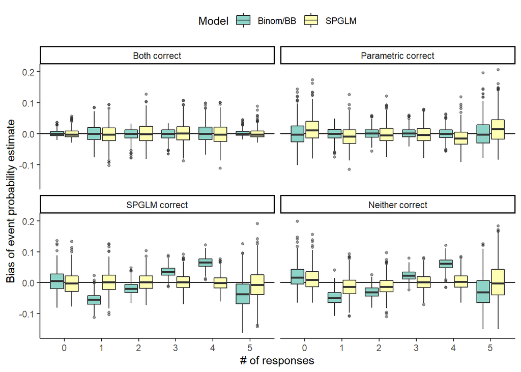

```r
ggplot(comb_pdf, aes(x=NResp, y=Est-Correct, fill=Model, outlier.fill=Model)) +
  facet_wrap(~Generator) +
  geom_hline(yintercept = 0, colour="black") +
 # stat_summary(aes(color=Model), fun=mean, geom="line") +
  geom_boxplot(aes(group=interaction(Model, NResp)),
               position=position_dodge(width=0.8), width=0.7,
               outlier.size =1, outlier.alpha=0.5) +
  scale_y_continuous("Bias of event probability estimate") +
  scale_x_continuous("# of responses", breaks = 0:cs_predict) +
  scale_fill_manual(breaks=names(cols), values=cols) +
  theme(legend.position = "top")
```